# Handling Speed and Pace with activatr

Daniel Schafer

`activatr` has utility functions to easily annotate a GPX DF with information about the speed (and corresponding pace) of an activity.

First, let’s parse our sample GPX DF:

```r
library(activatr)

# Get the running_example.gpx file included with this package.
filename <- system.file(
  "extdata",
  "running_example.gpx.gz",
  package = "activatr"
)

df <- parse_gpx(filename)
```

| lat | lon | ele | time |
| --- | --- | --- | --- |
| 37.80405 | -122.4267 | 17.0 | 2018-11-03 14:24:45 |
| 37.80406 | -122.4267 | 16.8 | 2018-11-03 14:24:46 |
| 37.80408 | -122.4266 | 17.0 | 2018-11-03 14:24:48 |
| 37.80409 | -122.4266 | 17.0 | 2018-11-03 14:24:49 |
| 37.80409 | -122.4265 | 17.2 | 2018-11-03 14:24:50 |

This has information about location and time, but it’s often useful to visualize the “mile pace” over the course of an activity, especially for runs.

The first thing to add to the table is the speed. `mutate_with_speed` is a wrapper around `dyplr::mutate` that will add a `speed` column to the data frame:

```r
df <- mutate_with_speed(df)
```

| lat | lon | ele | time | speed |
| --- | --- | --- | --- | --- |
| 37.80405 | -122.4267 | 17.0 | 2018-11-03 14:24:45 | NA |
| 37.80406 | -122.4267 | 16.8 | 2018-11-03 14:24:46 | 1.872248 |
| 37.80408 | -122.4266 | 17.0 | 2018-11-03 14:24:48 | 2.253735 |
| 37.80409 | -122.4266 | 17.0 | 2018-11-03 14:24:49 | 2.897343 |
| 37.80409 | -122.4265 | 17.2 | 2018-11-03 14:24:50 | 3.052919 |

However, speed (in meters per second) isn’t the most useful metric for runs; mile pace (in minutes and seconds) is a more common measurement. We can convert `speed` to `pace` using `speed_to_mile_pace`:

```r
df$pace <- speed_to_mile_pace(df$speed)
```

| lat | lon | ele | time | speed | pace |
| --- | --- | --- | --- | --- | --- |
| 37.80405 | -122.4267 | 17.0 | 2018-11-03 14:24:45 | NA | NA |
| 37.80406 | -122.4267 | 16.8 | 2018-11-03 14:24:46 | 1.872248 | 859.576123357018s (~14.33 minutes) |
| 37.80408 | -122.4266 | 17.0 | 2018-11-03 14:24:48 | 2.253735 | 714.076761564059s (~11.9 minutes) |
| 37.80409 | -122.4266 | 17.0 | 2018-11-03 14:24:49 | 2.897343 | 555.45378763746s (~9.26 minutes) |
| 37.80409 | -122.4265 | 17.2 | 2018-11-03 14:24:50 | 3.052919 | 527.147986228418s (~8.79 minutes) |

Finally, while `pace` here is a `lubridate` duration object, it’s most easily understood in a “MM:SS” format: `pace_formatter` is provided for that: contrast the readability of the two pace graphs below, the first plotting pace unmodified, the second reversing the axis and adding the formatter.

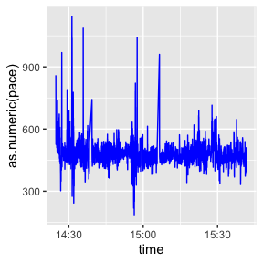

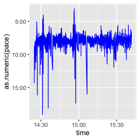

```r
library(ggplot2)
library(dplyr)
library(lubridate)
ggplot(filter(df, as.numeric(pace) < 1200)) +
  geom_line(aes(x = time, y = as.numeric(pace)), color = "blue")
ggplot(filter(df, as.numeric(pace) < 1200)) +
  geom_line(aes(x = time, y = as.numeric(pace)), color = "blue") +
  scale_y_reverse(label = pace_formatter)
```

Note that the speed and pace are calculated at every point, so they will often be somewhat noisy. Computing the rolling mean of the speed to smooth out the graph would be numerically inaccurate, so `mutate_with_speed` provides helper arguments to allow the speed to be computed over larger windows.

In particular, it has `lag` and `lead` (which default to `1` and `0` respectively), which determines the “start” and “end” points used for the speed computation. So if we wanted each point’s speed to be determined using the points ten ahead and ten behind and plot that, we could do:

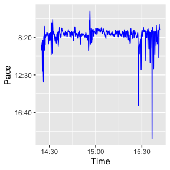

```r
df <- mutate_with_speed(df, lead = 10, lag = 10)
df$pace <- speed_to_mile_pace(df$speed)
ggplot(filter(df, as.numeric(pace) < 1200)) +
  geom_line(aes(x = time, y = as.numeric(pace)), color = "blue") +
  scale_y_reverse(label = pace_formatter) +
  xlab("Time") +
  ylab("Pace")
```